# IV Funktionen und Graphen

## 1. Strecken, Verschieben, Spiegeln von Graphen

**Beispiel:** $$\begin{align*} f(x)&=(x+2)^3\\ &= x^3+ 3x^2\cdot 2 +3x\cdot 4 + 8 \\ &= x^3 + 6x^2 +12x + 8 \end{align*} $$

**Exkurs:** Pascalsches Dreicek

[figure not shown]

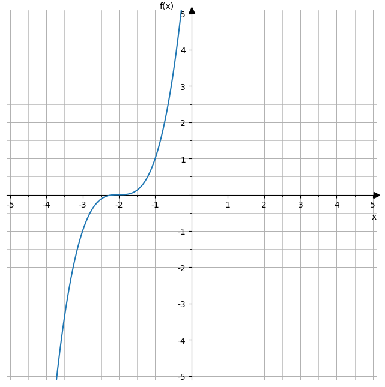

Wertetabelle:

[output not shown]

Fragen:

- Welche Auswirkung hat es , wenn man jeden Funktionswert mit der gleichen Zahl d=-1 addiert?

| x | -2 | -1 | 0 | 1 |
| --- | --- | --- | --- | --- |
| $$f(x)$$ | 0 | 1 | 8 | 27 |
| $$f(x)-1$$ | 0-1 | 1-1 | 8-1 | 27-1 |

=> Alle Punkte des Funktionsgraphen liegen um eine Einheit tiefer, als bei der Ausgangsfunktion.  
=> Verschiebung des Funktionsgraphen entlang der y-Achse.

- Welche Auswirkung hat es, wenn man jeden Funktionswert mit der gleichen Zahl a=2 multipliziert?

| x | -2 | -1 | 0 | 1 |
| --- | --- | --- | --- | --- |
| $$f(x)$$ | 0 | 1 | 8 | 27 |
| $$2\cdot f(x)$$ | 0 | 2 | 16 | 54 |

- Welche Auswirkung hat es, wenn man jeden Funktionswert mit der gleichen Zahl a=-1 multipliziert?

| x | -2 | -1 | 0 | 1 |
| --- | --- | --- | --- | --- |
| $$f(x)$$ | 0 | 1 | 8 | 27 |
| $$-1\cdot f(x)$$ | 0 | -1 | -8 | -27 |

=> Alle y-Werte der Punkte des ursprünglichen Funktionsgraphen erhalten das entegengesetzte Vorzeichen.  
=> Speigelung des ursprünglichen Funktionsgraphen an der x-Achse.

- Welche Auswirkung hat es, wenn man von jeden x-Wert die gleiche Zahl c=2 subrahiert.

| x | -2 | -1 | 0 | 1 |
| --- | --- | --- | --- | --- |
| $$f(x)$$ | 0 | 1 | 8 | 27 |
| $$f(x-2)$$ | -8 | -1 | 0 | 1 |

=> Alle Punkte des Funktionsgraphen haben den Funktionswert, den der ursprüngliche Graph schon zwei Einheiten weiter links gehabt hat.  
=> Der Graph wird verschoben auf entlang der x-Achse.

**Satz:**  
Der Graph der Funktion g mit $g(x)=a\cdot f(x-c)+d,$ mit $a, c, d \in \mathbb{R}, \quad a\neq 0$ entsteht aus dem Graphen der Funktion $f$ durch

- Streckung in y-Richtung mit dem Faktor $|a|$
- Verschiebung entlag der y-Achse um d
- Verschiebung entlang der x-Achse um c.

**Beispiel:** $$ f(x)=e^x $$

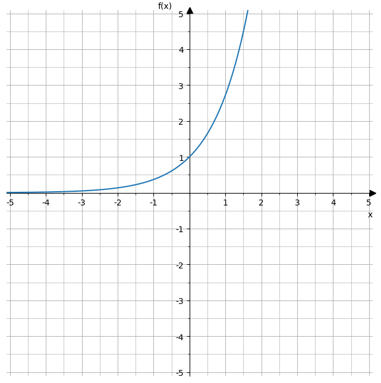

Wertetabelle:

| x | -2 | -1 | 0 | 1 |
| --- | --- | --- | --- | --- |
| $$f(x)$$ | 0,135 | 0,368 | 1 | $$e$$ |

Fragen:

- Welche Auswirkung hat es , wenn man jeden Funktionswert mit -1 ?

| x | -2 | -1 | 0 | 1 |
| --- | --- | --- | --- | --- |
| $$f(x)$$ | 0,135 | 0,368 | 1 | $$e$$ |
| $$-f(x)$$ | -0,135 | -0,368 | -1 | $$-e$$ |

=> Die y-Koordinaten aller Punkte des Grapen werden negativ.

=> Spiegelung des Funktionsgraphen an der x-Achse.

- Welche Auswirkung hat es , wenn man die Funktionsvariable mit -1 multipliziert?

| x | -2 | -1 | 0 | 1 |
| --- | --- | --- | --- | --- |
| $$f(x)$$ | 0,135 | 0,368 | 1 | $$e$$ |
| $$f(-x)$$ | 7,389 | $e$ | 1 | 0,386 |

=> Alle Punkte des Grahen erhalten die y-Koordinaten ihrer negativen Pendants.

=> Spiegelung des Funktionsgraphen an der y-Achse.

- Welche Auswirkung hat es , wenn man die Funktionsvariable mit -1 multipliziert und den Funktionswert auch mnit -1?

| x | -2 | -1 | 0 | 1 |
| --- | --- | --- | --- | --- |
| $$ f(x) $$ | 0,135 | 0,368 | 1 | $$e$$ |
| $$f(-x)$$ | -7,389 | $$-e$$ | -1 | -0,386 |

=> Alle Punkte des Grahen erhalten die y-Koordinaten ihrer negativen Pendants.

=> Alle y-kooridnaten der Punkte erhalten das entegegensgesetzte Vorzeichen.

=> Spiegelung des Funktionsgraphen am Ursprung $O(0|0)$

**Satz:**  
Der Graph der Funktion $g$ entsteht aus dem Graphen der Funktion $f$ durch

- $g(x)= f(-x)$ mit einer Spiegelung an der y-Achse.
- $g(x)= -f(x)$ mit einer Spiegelung an der x-Achse.
- $g(x)= -f(-x)$ mit einerSpiegelung am Ursprung $O(0|0)$

**Nachweis einer Achsensymmetrie zur y-Achse bzw. einer Punktsymmetrie zum Ursprung:**

**Satz:**

Der Graph einer Funktion f ist genau dann

- achsensymmetrisch zur y-Achse, wenn für alle $x \in D_f$ gil: $f(-x)=f(x)$
- punktsymmetrisch zum Ursprung, wenn für alle $x \in D_f$ gil: $f(-x)=-f(x)$

**Beispiel:** $$ \begin{align*} f(x) &=x\cdot \sin(x)\\ f(-x)&=-x \cdot \sin(-x)\\ &= -(x\cdot \sin(-x))\\ &=-(x \cdot (-\sin(x))\\ &=x\cdot \sin(x) \end{align*} $$

$\Rightarrow$ Achsensymmetrie zur y-Achse.

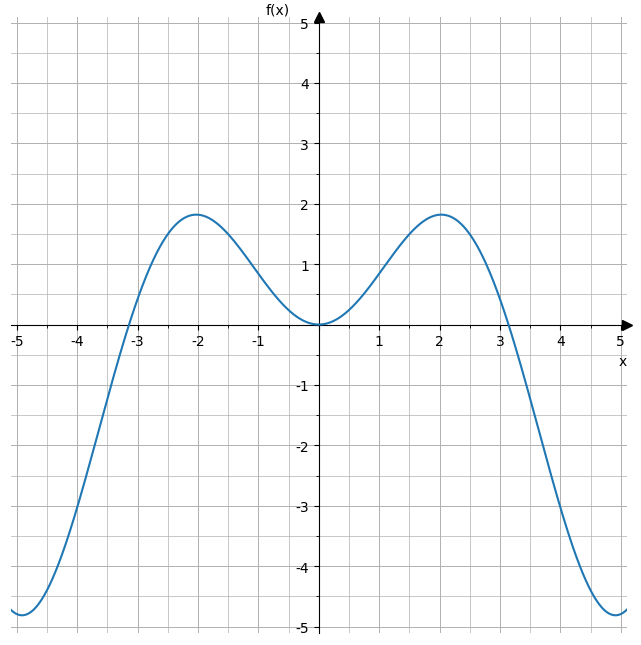